# Jensen Beach to Jupiter Inlet Aquatic Preserve

SEACAR Water Quality Analysis

Last compiled on 15 July, 2026

# Indicators

## Nutrients

### Total Nitrogen - Discrete

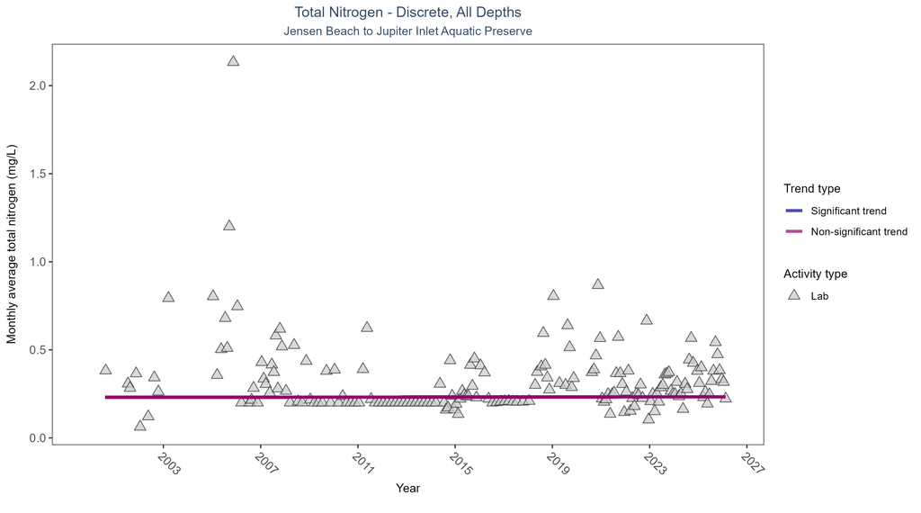

Scatter plot of monthly average total nitrogen over time. If the time series included ten or more years of discrete observations, a significant (blue) or non-significant (magenta) trend line is also shown. Only nitrogen values obtained from laboratory analyses (triangles) are included in the plot.

Table:

Total nitrogen showed no detectable trend between 2000 and 2026.

| Activity Type | Statistical Trend | Sample Count | Years with Data | Period of Record | Median Result Value | Tau | Sen Intercept | Sen Slope | P |
| --- | --- | --- | --- | --- | --- | --- | --- | --- | --- |
| Lab | No detectable trend | 742 | 26 | 2000 - 2026 | 0.2615 | 0.0551 | 0.23023 | 0.00012 | 0.3333 |

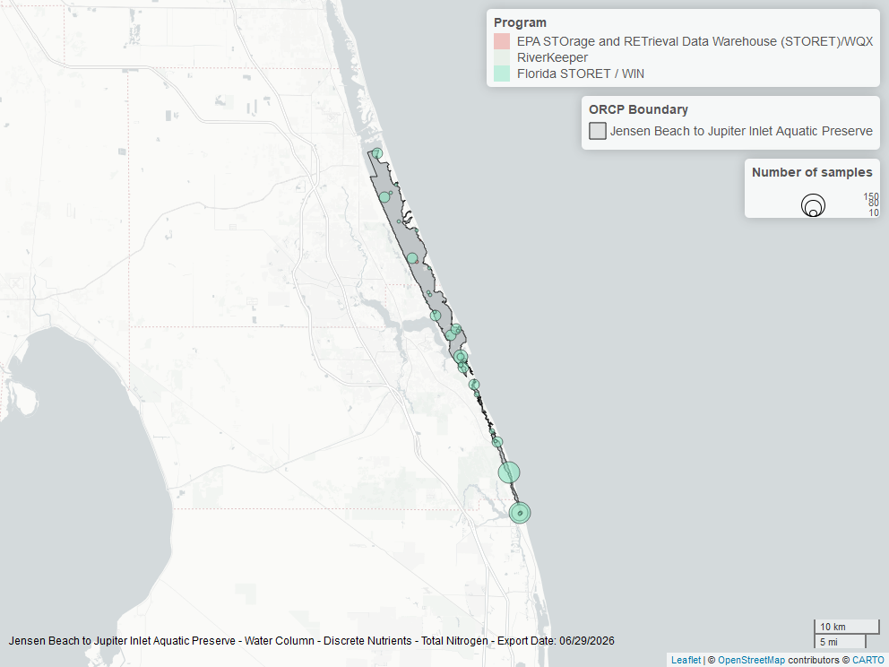

Map showing location of discrete water quality sampling locations within the boundaries of *Jensen Beach to Jupiter Inlet Aquatic Preserve*. The bubble size on the maps above reflect the amount of data available at each sampling site.

### Total Phosphorus - Discrete

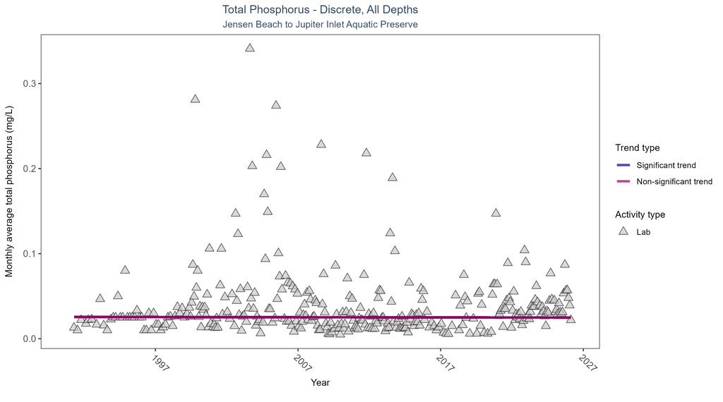

Scatter plot of monthly average total phosphorus over time. If the time series included ten or more years of discrete observations, a significant (blue) or non-significant (magenta) trend line is also shown. Only phosphorus values obtained from laboratory analyses (triangles) are included in the plot.

Table:

Total phosphorus showed no detectable trend between 1991 and 2026.

| Activity Type | Statistical Trend | Sample Count | Years with Data | Period of Record | Median Result Value | Tau | Sen Intercept | Sen Slope | P |
| --- | --- | --- | --- | --- | --- | --- | --- | --- | --- |
| Lab | No detectable trend | 1175 | 36 | 1991 - 2026 | 0.027 | -0.02114 | 0.02555 | -0.00002 | 0.8002 |

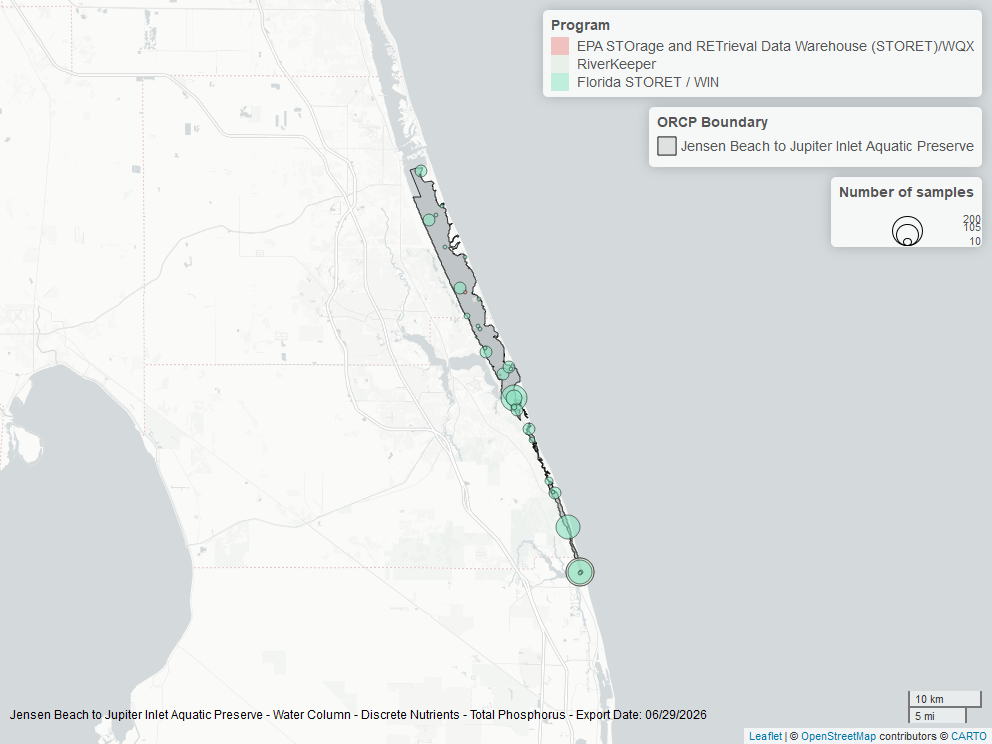

Map showing location of discrete water quality sampling locations within the boundaries of *Jensen Beach to Jupiter Inlet Aquatic Preserve*. The bubble size on the maps above reflect the amount of data available at each sampling site.

## Water Quality

### Dissolved Oxygen - Discrete

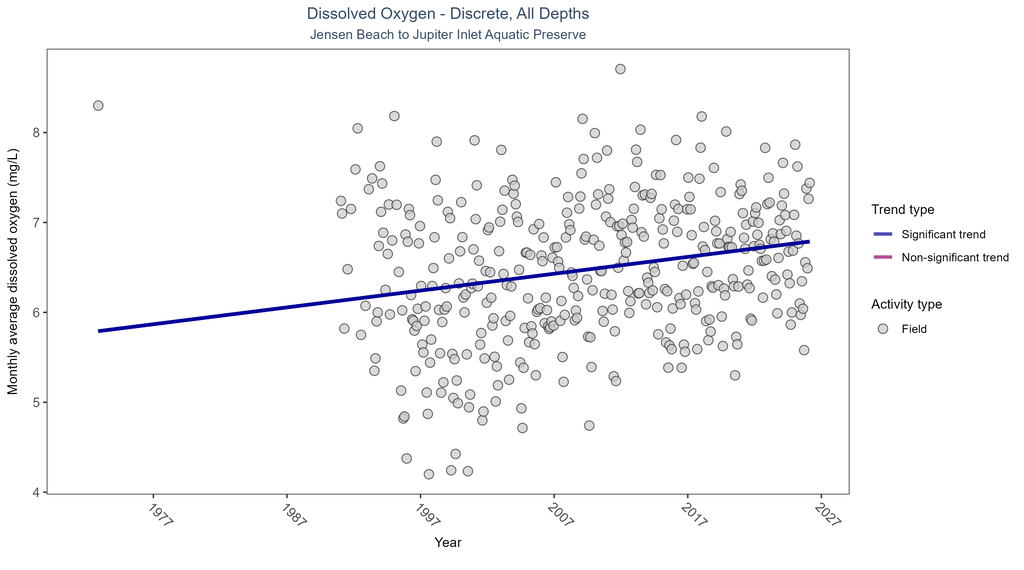

Scatter plot of monthly average dissolved oxygen over time. If the time series included ten or more years of discrete observations, a significant (blue) or non-significant (magenta) trend line is also shown. Only dissolved oxygen values measured in the field (circles) are included in the plot.

Table:

Monthly average dissolved oxygen increased by 0.02 mg/L per year.

| Activity Type | Statistical Trend | Sample Count | Years with Data | Period of Record | Median Result Value | Tau | Sen Intercept | Sen Slope | P |
| --- | --- | --- | --- | --- | --- | --- | --- | --- | --- |
| Field | Increasing trend | 11083 | 37 | 1972 - 2026 | 6.42 | 0.21627 | 5.77463 | 0.01872 | 0 |

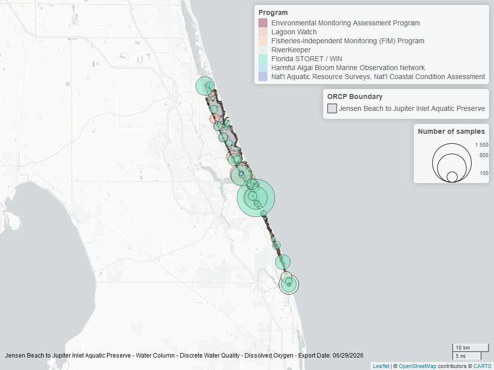

Map showing location of discrete water quality sampling locations within the boundaries of *Jensen Beach to Jupiter Inlet Aquatic Preserve*. The bubble size on the maps above reflect the amount of data available at each sampling site.

### Dissolved Oxygen Saturation - Discrete

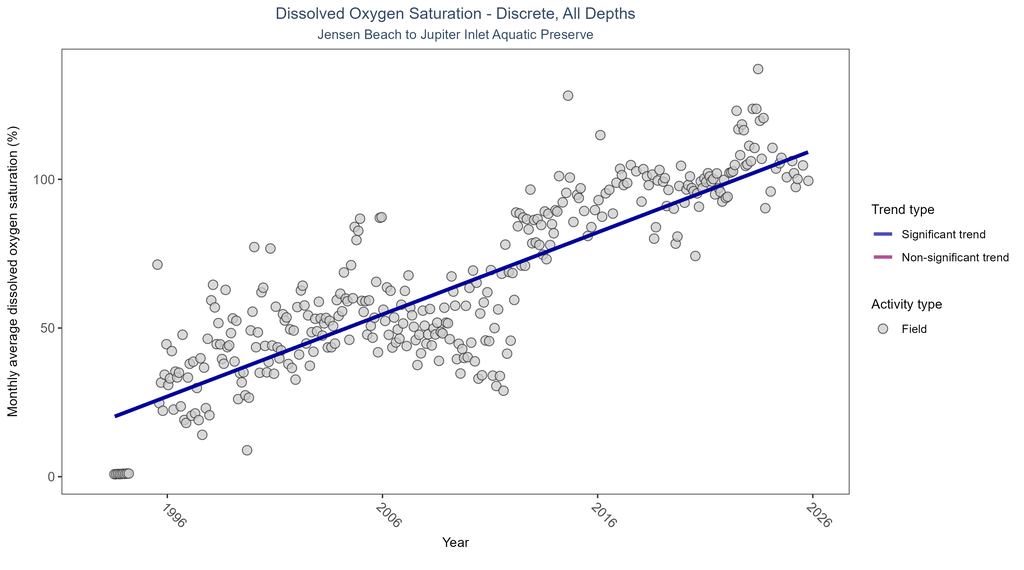

Scatter plot of monthly average dissolved oxygen saturation over time. If the time series included ten or more years of discrete observations, a significant (blue) or non-significant (magenta) trend line is also shown. Only dissolved oxygen saturation values measured in the field (circles) are included in the plot.

Table:

Monthly average dissolved oxygen saturation increased by 2.76% per year.

| Activity Type | Statistical Trend | Sample Count | Years with Data | Period of Record | Median Result Value | Tau | Sen Intercept | Sen Slope | P |
| --- | --- | --- | --- | --- | --- | --- | --- | --- | --- |
| Field | Increasing trend | 4302 | 33 | 1993 - 2025 | 80 | 0.68087 | 18.71729 | 2.75845 | 0 |

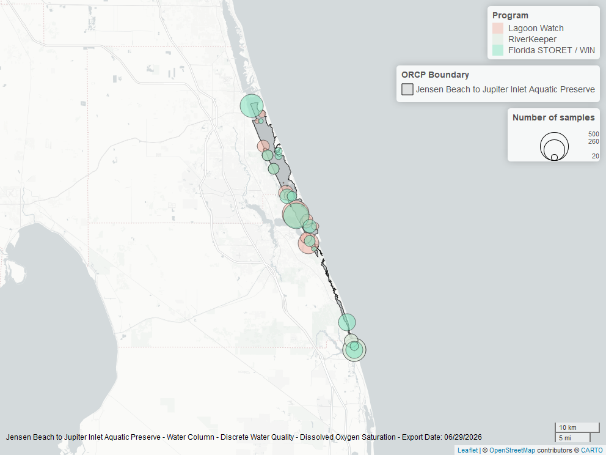

Map showing location of discrete water quality sampling locations within the boundaries of *Jensen Beach to Jupiter Inlet Aquatic Preserve*. The bubble size on the maps above reflect the amount of data available at each sampling site.

### Salinity - Discrete

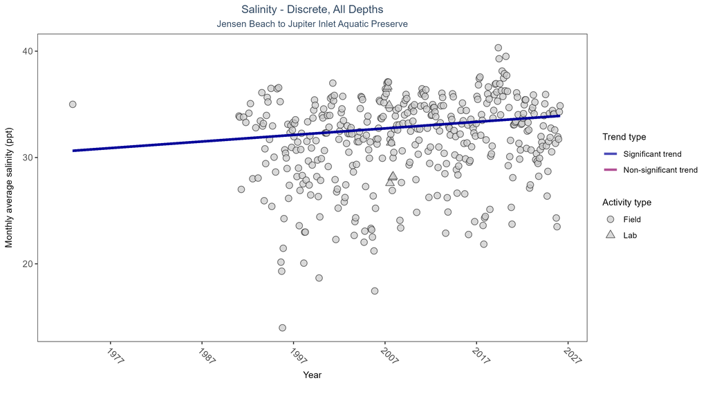

Scatter plot of monthly average salinity over time. If the time series included ten or more years of discrete observations, significant (blue) or non-significant (magenta) trend lines are also shown. Discrete salinity values derived from grab samples analyzed in the field (circles) or the laboratory (triangles) are both included in the plot.

Table:

Monthly average salinity increased by 0.06 ppt per year.

| Activity Type | Statistical Trend | Sample Count | Years with Data | Period of Record | Median Result Value | Tau | Sen Intercept | Sen Slope | P |
| --- | --- | --- | --- | --- | --- | --- | --- | --- | --- |
| All | Increasing trend | 11371 | 37 | 1972 - 2026 | 32.8 | 0.1335 | 30.58017 | 0.0616 | 0.0001 |

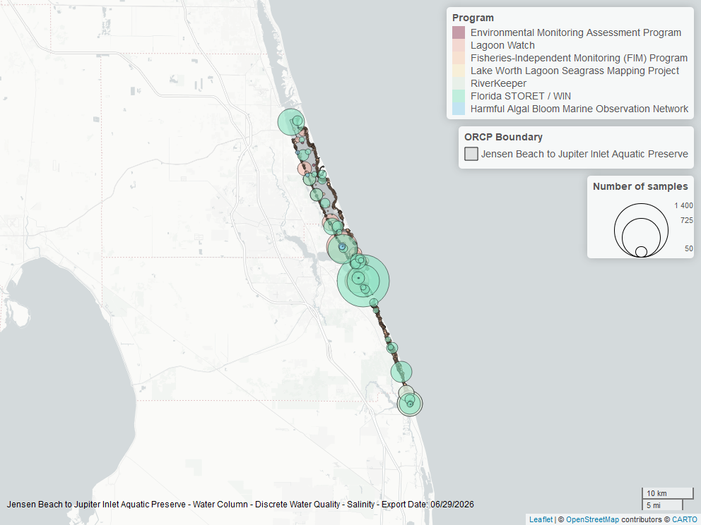

Map showing location of discrete water quality sampling locations within the boundaries of *Jensen Beach to Jupiter Inlet Aquatic Preserve*. The bubble size on the maps above reflect the amount of data available at each sampling site.

### Salinity - Continuous

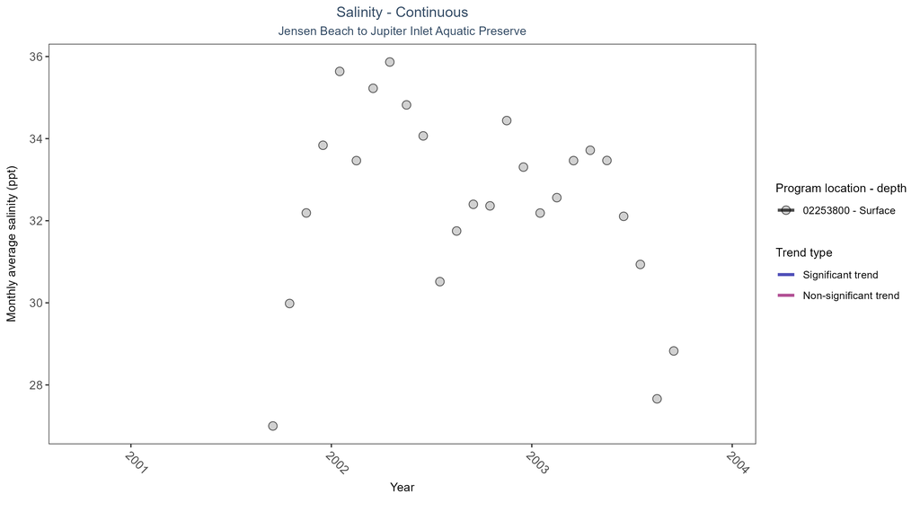

Scatter plot of monthly average salinity over time at continuously monitored program locations. Each location is analyzed separately, with significant (blue) or non-significant (magenta) trend lines shown for time series that included five or more years of observations.

Table:

There was insufficient data to fit a model for one location.

| Program Location | Statistical Trend | Sample Count | Years with Data | Period of Record | Median Result Value | Tau | Sen Intercept | Sen Slope | P |
| --- | --- | --- | --- | --- | --- | --- | --- | --- | --- |
| 02253800 | Insufficient data | 1213 | 3 | 2001 - 2003 | 33 | - | - | - | - |

[figure not shown]

Map showing location of salinity continuous water quality sampling locations within the boundaries of *Jensen Beach to Jupiter Inlet Aquatic Preserve*. The bubble size on the maps above reflect the amount of data available at each sampling site.

### Water Temperature - Continuous

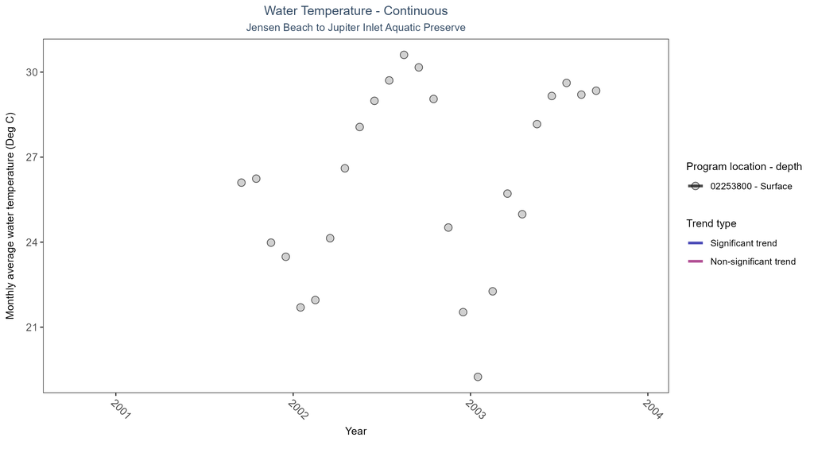

Scatter plot of monthly average water temperature over time at continuously monitored program locations. Each location is analyzed separately, with significant (blue) or non-significant (magenta) trend lines shown for time series that included five or more years of observations.

Table:

There was insufficient data to fit a model for one location.

| Program Location | Statistical Trend | Sample Count | Years with Data | Period of Record | Median Result Value | Tau | Sen Intercept | Sen Slope | P |
| --- | --- | --- | --- | --- | --- | --- | --- | --- | --- |
| 02253800 | Insufficient data | 1186 | 3 | 2001 - 2003 | 27.1 | - | - | - | - |

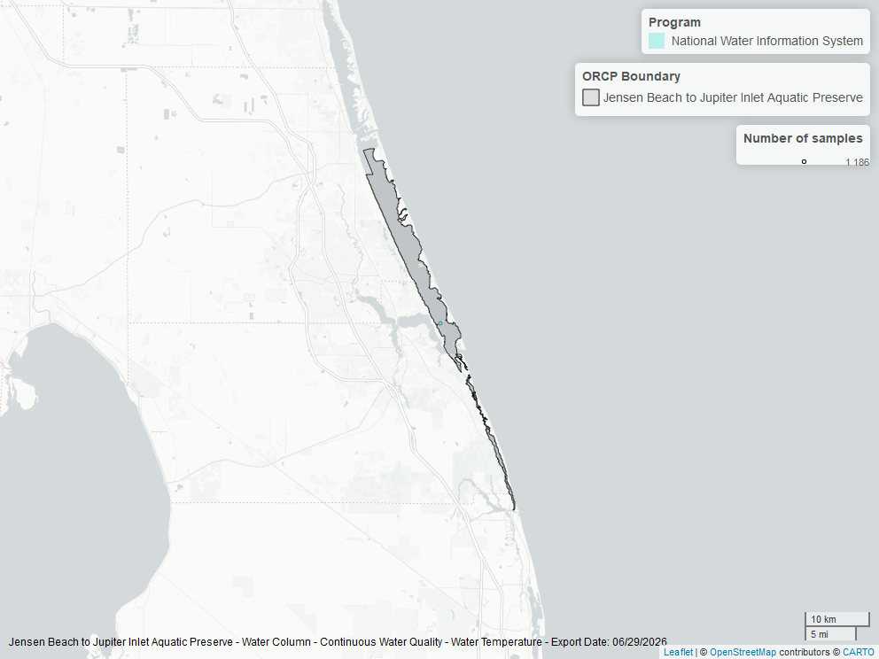

Map showing location of water temperature continuous water quality sampling locations within the boundaries of *Jensen Beach to Jupiter Inlet Aquatic Preserve*. The bubble size on the maps above reflect the amount of data available at each sampling site.

### Water Temperature - Discrete

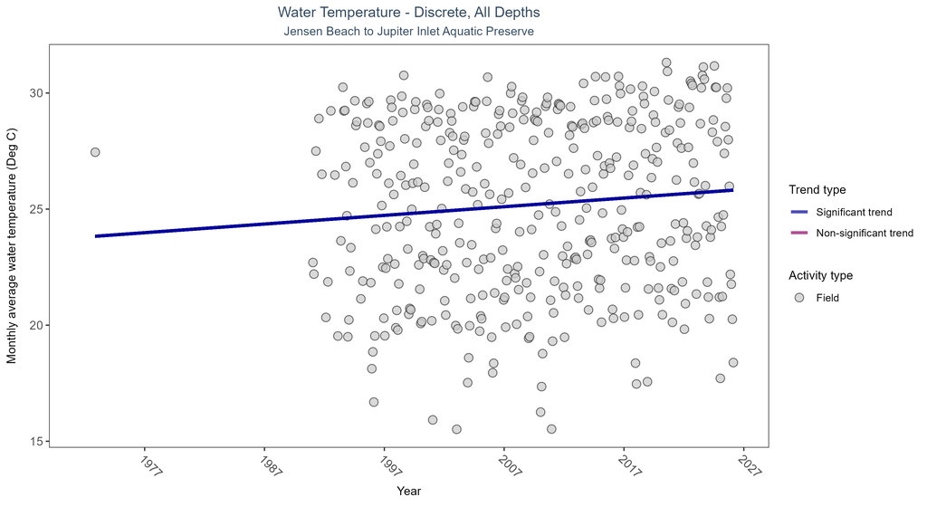

Scatter plot of monthly average water temperature over time. If the time series included ten or more years of discrete observations, a significant (blue) or non-significant (magenta) trend line is also shown. Only water temperature measurements taken in the field (circles) are included in the plot.

Table:

Monthly average water temperature increased by 0.04°C per year.

| Activity Type | Statistical Trend | Sample Count | Years with Data | Period of Record | Median Result Value | Tau | Sen Intercept | Sen Slope | P |
| --- | --- | --- | --- | --- | --- | --- | --- | --- | --- |
| Field | Increasing trend | 11131 | 37 | 1972 - 2026 | 25.5 | 0.21646 | 23.79669 | 0.03731 | 0 |

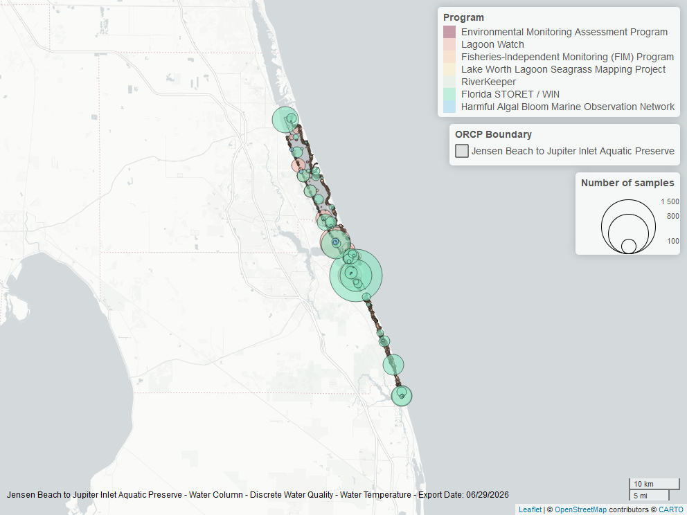

Map showing location of discrete water quality sampling locations within the boundaries of *Jensen Beach to Jupiter Inlet Aquatic Preserve*. The bubble size on the maps above reflect the amount of data available at each sampling site.

### pH - Discrete

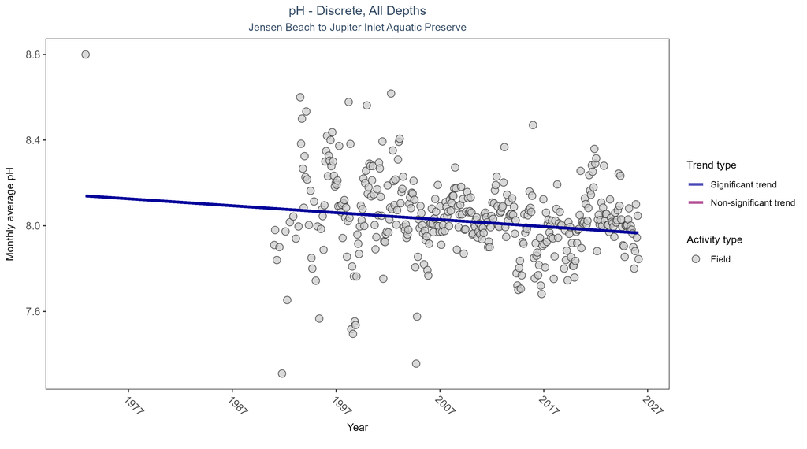

Scatter plot of monthly average pH over time. If the time series included ten or more years of discrete observations, a significant (blue) or non-significant (magenta) trend line is also shown. Only pH values measured in the field (circles) are included in the plot.

Table:

Monthly average pH decreased by less than 0.01 pH units per year.

| Activity Type | Statistical Trend | Sample Count | Years with Data | Period of Record | Median Result Value | Tau | Sen Intercept | Sen Slope | P |
| --- | --- | --- | --- | --- | --- | --- | --- | --- | --- |
| Field | Decreasing trend | 10057 | 37 | 1972 - 2026 | 8.01 | -0.15018 | 8.14225 | -0.00325 | 0 |

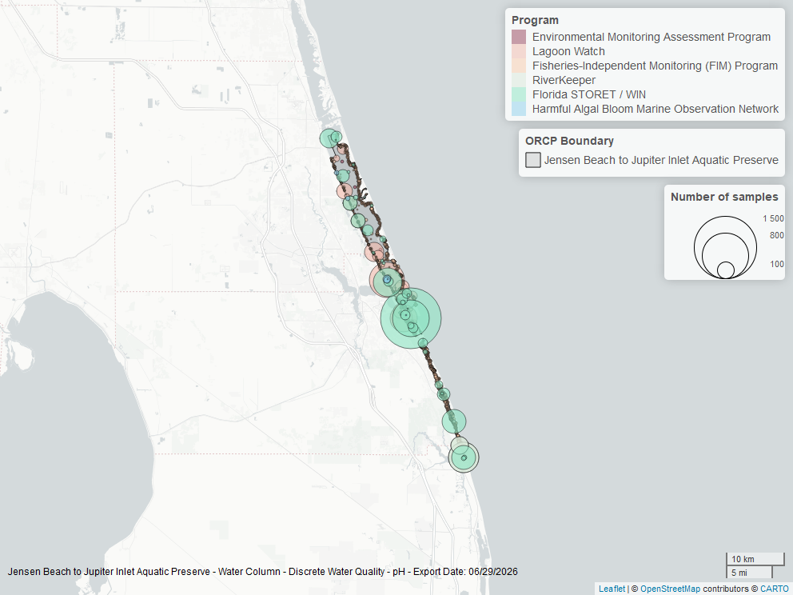

Map showing location of discrete water quality sampling locations within the boundaries of *Jensen Beach to Jupiter Inlet Aquatic Preserve*. The bubble size on the maps above reflect the amount of data available at each sampling site.

## Water Clarity

### Turbidity - Discrete

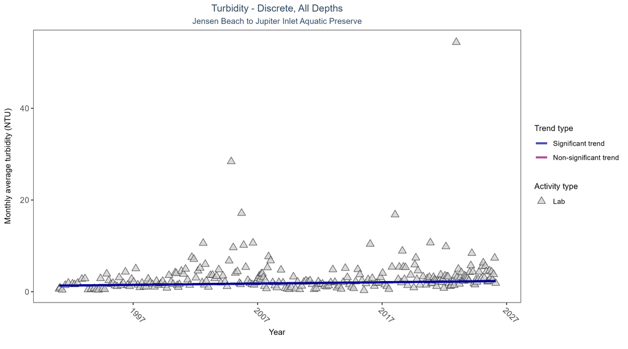

Scatter plot of monthly average turbidity over time. If the time series included ten or more years of discrete observations, a significant (blue) or non-significant (magenta) trend line is also shown. Only turbidity values measured in the laboratory (triangles) are included in the plot.

Table:

Monthly average turbidity increased by 0.03 NTU per year, indicating a decrease in water clarity.

| Activity Type | Statistical Trend | Sample Count | Years with Data | Period of Record | Median Result Value | Tau | Sen Intercept | Sen Slope | P |
| --- | --- | --- | --- | --- | --- | --- | --- | --- | --- |
| Lab | Increasing trend | 986 | 36 | 1991 - 2026 | 2.3 | 0.13945 | 1.3314 | 0.02821 | 0.0039 |

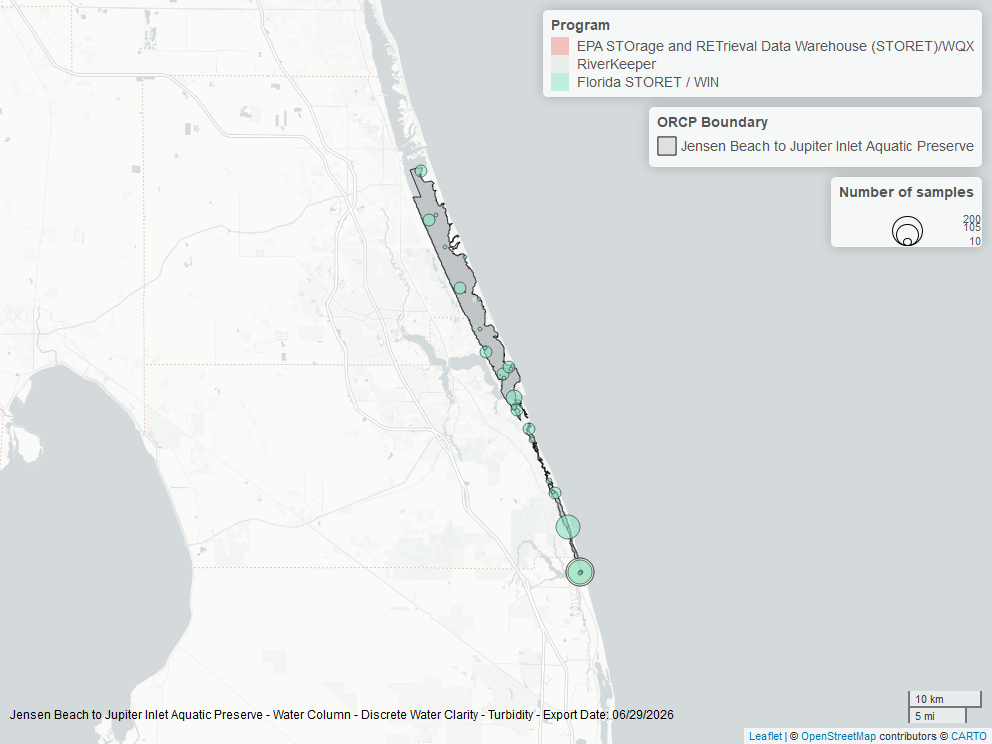

Map showing location of discrete water quality sampling locations within the boundaries of *Jensen Beach to Jupiter Inlet Aquatic Preserve*. The bubble size on the maps above reflect the amount of data available at each sampling site.

### Total Suspended Solids - Discrete

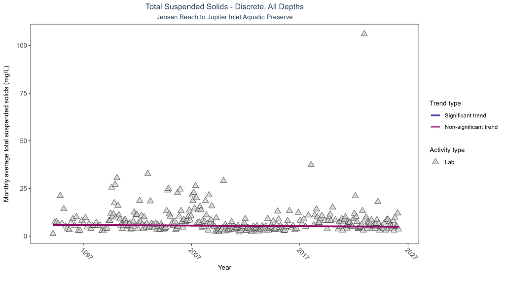

Scatter plot of monthly average total suspended solids (TSS) over time. If the time series included ten or more years of discrete observations, a significant (blue) or non-significant (magenta) trend line is also shown. Only TSS values obtained from laboratory analyses (triangles) are included in the plot.

Table:

Total suspended solids showed no detectable trend between 1994 and 2026.

| Activity Type | Statistical Trend | Sample Count | Years with Data | Period of Record | Median Result Value | Tau | Sen Intercept | Sen Slope | P |
| --- | --- | --- | --- | --- | --- | --- | --- | --- | --- |
| Lab | No detectable trend | 1303 | 33 | 1994 - 2026 | 6 | -0.07224 | 5.90251 | -0.03156 | 0.0969 |

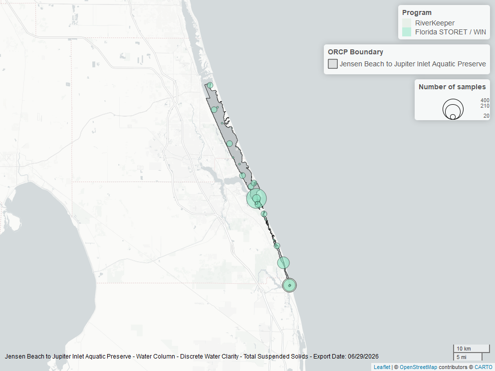

Map showing location of discrete water quality sampling locations within the boundaries of *Jensen Beach to Jupiter Inlet Aquatic Preserve*. The bubble size on the maps above reflect the amount of data available at each sampling site.

### Chlorophyll a, Uncorrected for Pheophytin - Discrete

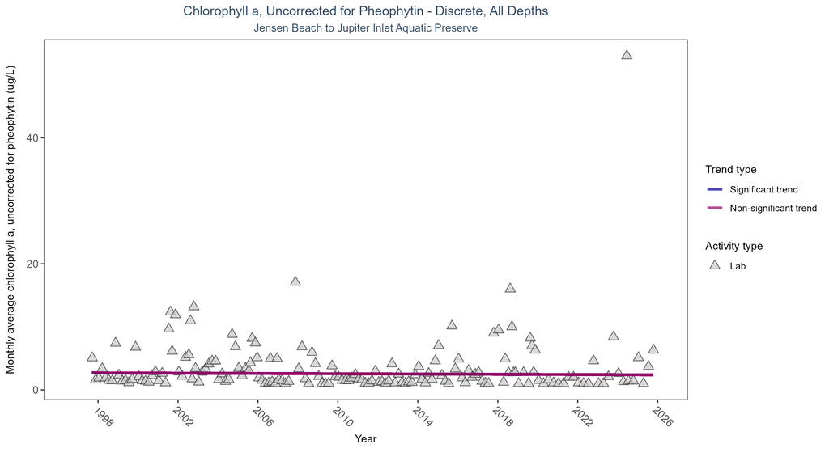

Scatter plot of monthly average levels of chlorophyll a, uncorrected for pheophytin, over time. If the time series included ten or more years of discrete observations, a significant (blue) or non-significant (magenta) trend line is also shown. Only laboratory-analyzed chlorophyll a (triangles) is included in the plot.

Table:

Chlorophyll a, uncorrected for pheophytin, showed no detectable trend between 1997 and 2025.

| Activity Type | Statistical Trend | Sample Count | Years with Data | Period of Record | Median Result Value | Tau | Sen Intercept | Sen Slope | P |
| --- | --- | --- | --- | --- | --- | --- | --- | --- | --- |
| Lab | No detectable trend | 479 | 29 | 1997 - 2025 | 2 | -0.10169 | 2.70475 | -0.01111 | 0.1899 |

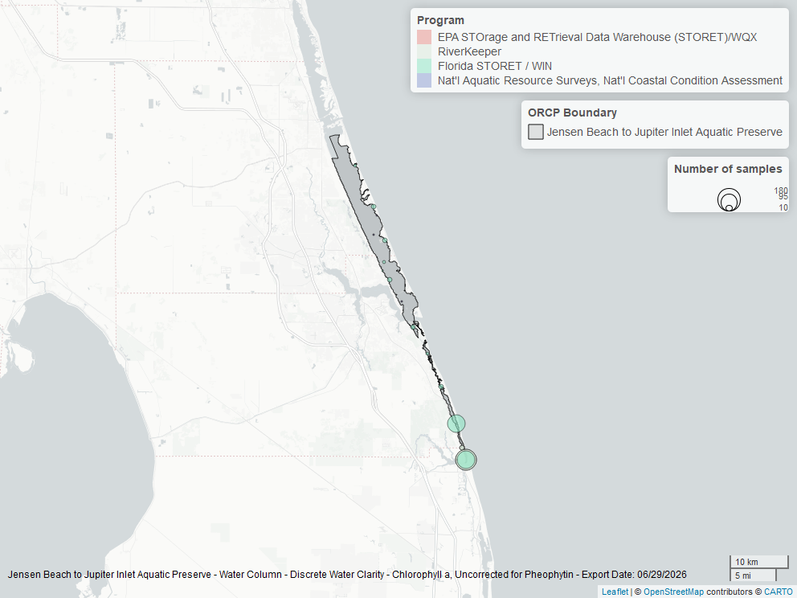

Map showing location of discrete water quality sampling locations within the boundaries of *Jensen Beach to Jupiter Inlet Aquatic Preserve*. The bubble size on the maps above reflect the amount of data available at each sampling site.

### Chlorophyll a, Corrected for Pheophytin - Discrete

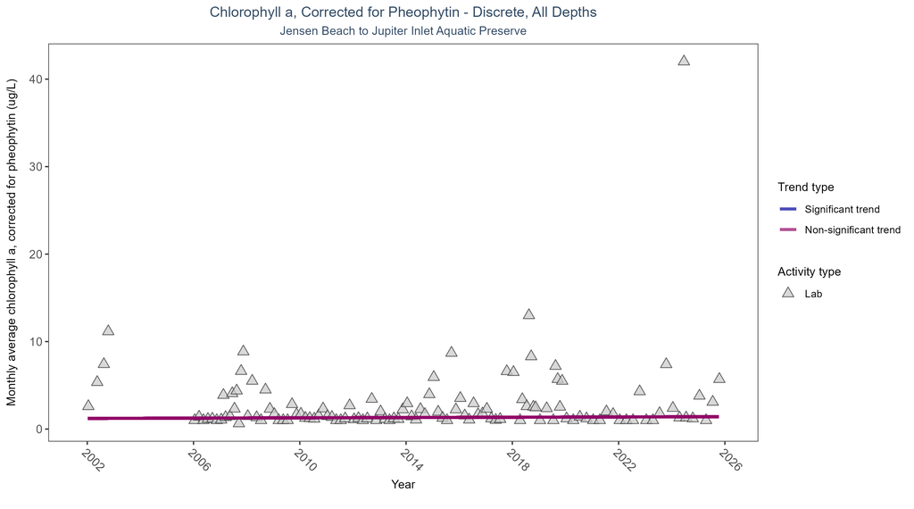

Scatter plot of monthly average levels of chlorophyll a, corrected for pheophytin, over time. If the time series included ten or more years of discrete observations, a significant (blue) or non-significant (magenta) trend line is also shown. Only laboratory-analyzed chlorophyll a (triangles) is included in the plot.

Table:

Chlorophyll a, corrected for pheophytin, showed no detectable trend between 2002 and 2025.

| Activity Type | Statistical Trend | Sample Count | Years with Data | Period of Record | Median Result Value | Tau | Sen Intercept | Sen Slope | P |
| --- | --- | --- | --- | --- | --- | --- | --- | --- | --- |
| Lab | No detectable trend | 349 | 21 | 2002 - 2025 | 1.4 | 0.09098 | 1.21844 | 0.00833 | 0.1673 |

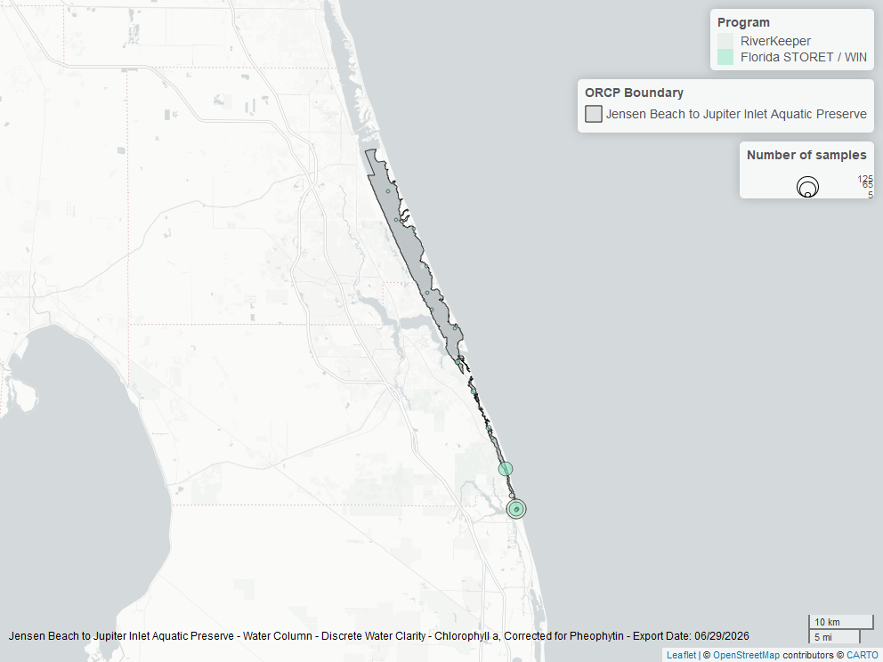

Map showing location of discrete water quality sampling locations within the boundaries of *Jensen Beach to Jupiter Inlet Aquatic Preserve*. The bubble size on the maps above reflect the amount of data available at each sampling site.

### Secchi Depth - Discrete

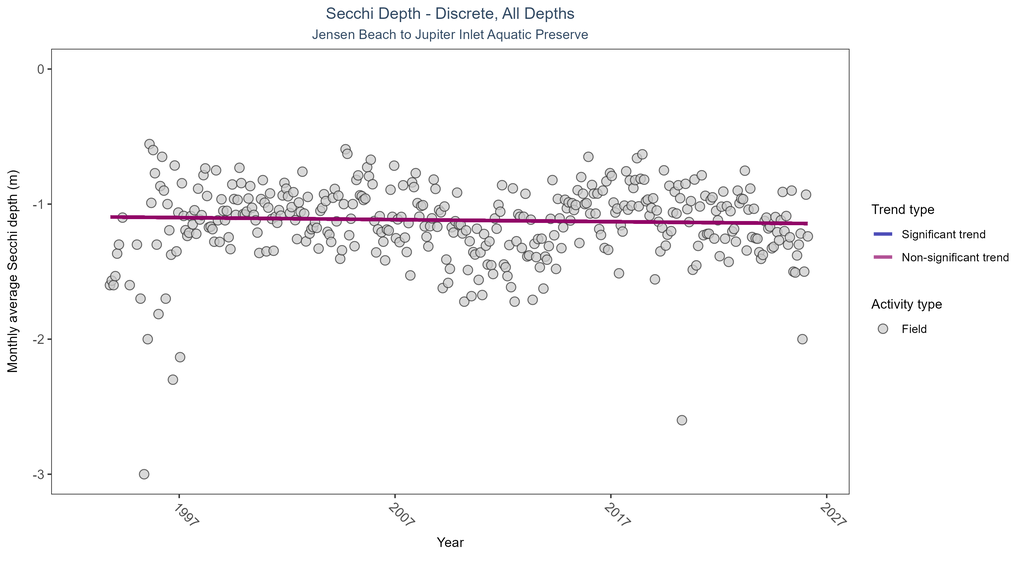

Scatter plot of monthly average Secchi depth over time. If the time series included ten or more years of discrete observations, a significant (blue) or non-significant (magenta) trend line is also shown. Secchi depth is only measured in the field (circles).

Table:

Secchi depth showed no detectable trend between 1993 and 2026.

| Activity Type | Statistical Trend | Sample Count | Years with Data | Period of Record | Median Result Value | Tau | Sen Intercept | Sen Slope | P |
| --- | --- | --- | --- | --- | --- | --- | --- | --- | --- |
| Field | No detectable trend | 6588 | 34 | 1993 - 2026 | -1 | -0.03632 | -1.09407 | -0.0015 | 0.336 |

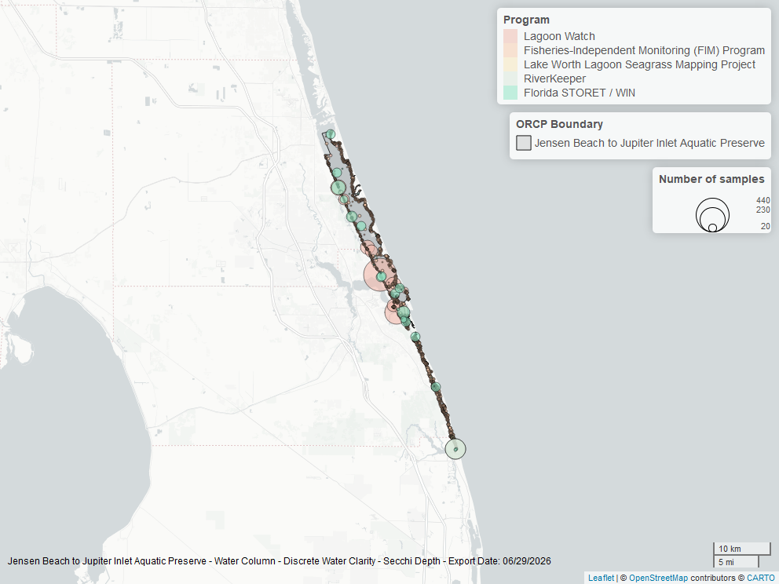

Map showing location of discrete water quality sampling locations within the boundaries of *Jensen Beach to Jupiter Inlet Aquatic Preserve*. The bubble size on the maps above reflect the amount of data available at each sampling site.

### Colored Dissolved Organic Matter - Discrete

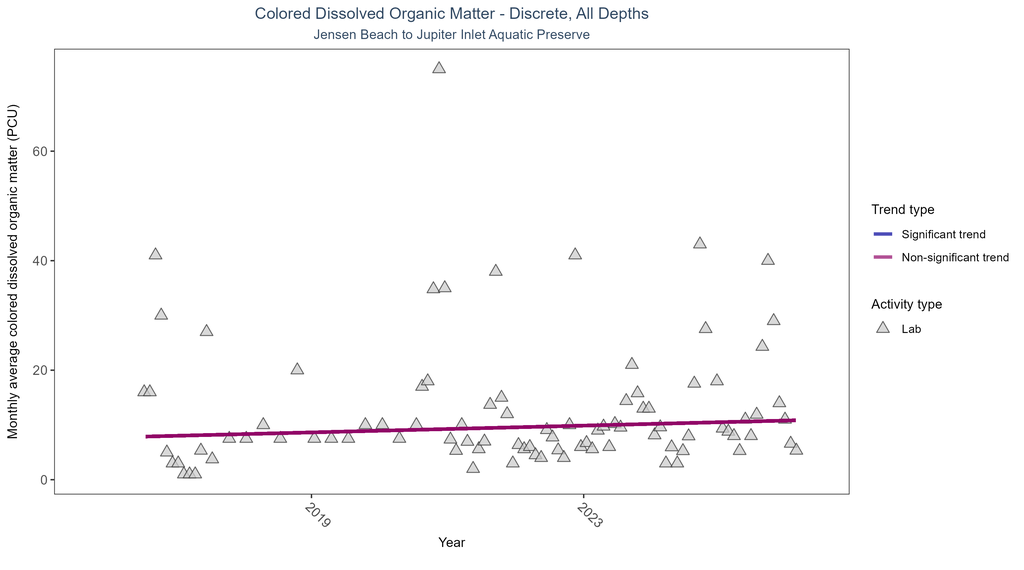

Scatter plot of monthly average colored dissolved organic matter (CDOM) over time. If the time series included ten or more years of discrete observations, a significant (blue) or non-significant (magenta) trend line is also shown. Only laboratory-analyzed CDOM (triangles) is included in the plot.

Table:

Colored dissolved organic matter showed no detectable trend between 2016 and 2026.

| Activity Type | Statistical Trend | Sample Count | Years with Data | Period of Record | Median Result Value | Tau | Sen Intercept | Sen Slope | P |
| --- | --- | --- | --- | --- | --- | --- | --- | --- | --- |
| Lab | No detectable trend | 434 | 11 | 2016 - 2026 | 7.5 | 0.1522 | 7.70455 | 0.31061 | 0.0934 |

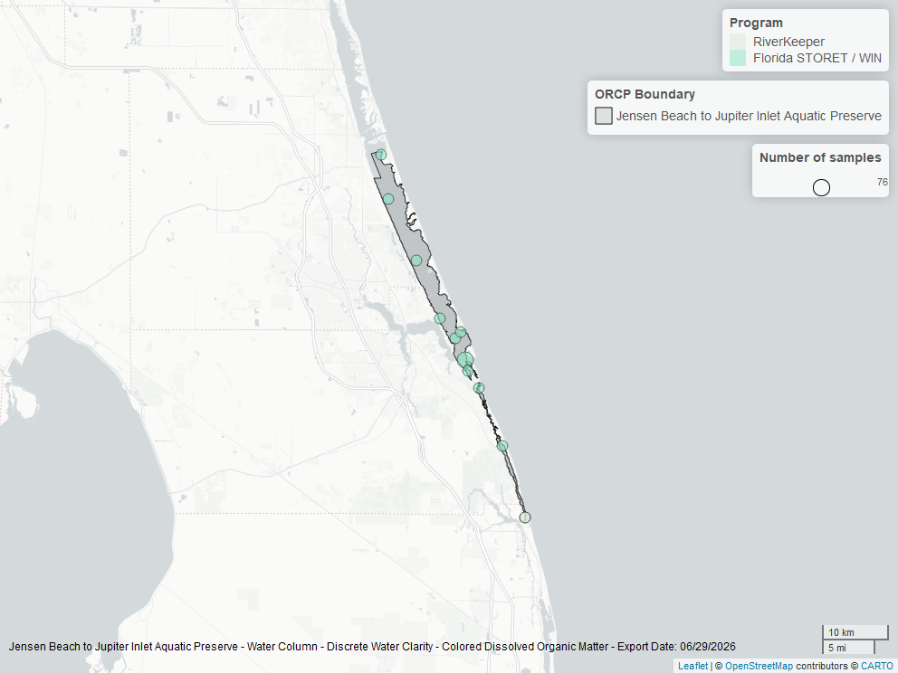

Map showing location of discrete water quality sampling locations within the boundaries of *Jensen Beach to Jupiter Inlet Aquatic Preserve*. The bubble size on the maps above reflect the amount of data available at each sampling site.